# Updates (June 5th, 2020)

## TL;DR - Test Set accuracy ~ 75%, next: hard coded optimizations; losses!

Since the last update:

- Approved to use the Men's data
- Labeled more data
- Committee: Eric, Brian, Anne

Next steps:

- Finish first draft (with a few holes)
- Can we create a new loss function?
- Labeling/hard coding decision rules in the data
- Look into Generative Adversarial Networks
- Goal: ~July 15 defense date
- Goal: Submit to a journal
  - http://www.sloansportsconference.com/activities/research-papers/2019-research-paper-finalists-posters/
  - https://community.amstat.org/sis/journals

## 0: Literature Review:

(outlines of this coming soon)

- https://dspace.mit.edu/handle/1721.1/119728
- https://dash.harvard.edu/handle/1/17463133

## 1: Gap #1

**Can we train a classifier to correctly classify the following actions within a possession of ShotTracker data?** (http://developer.shottracker.com/#stats-stats-possessions-get for API reference):

- On-ball screen
- UCLA screen
- Pin-down screen
- Flare screen
- Backdoor cut
- Rubcut/handoff

## 2: Gap #2

**Is there a relationship between the actions that happen in a possession and the outcome?**

Goal: regression with points, rebounds, etc.

- Does this analysis allow us to generalize to the whole game of basketball? (tougher question to answer)
- Using coaching literature, we might be able to say stuff about this relationship in the college game

## 3: Filling Gap #1 (a sample):

Play (or click through) the clip below to see an example of a possession (courtlines will be added soon to help see things)

[figure not shown]

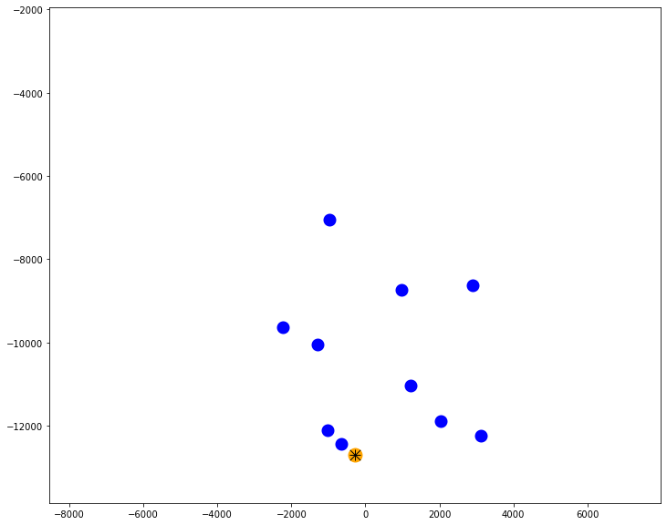

```python
mypossession = 1582588196315
s = 'http://api.shottracker.com/v1/data/sensors/locations/possessions/'+str(mypossession)+'?team_id=1930'
p = shottracker_request(path=s.replace('http://api.shottracker.com',''))
myframes = []
for location in p.json().get('locations'):
        myframes.append(pd.DataFrame(json.loads(json.dumps(location.get('placements')))))

fig = plt.figure(figsize = (12,10))
ims = []
for frame in myframes:
    players = frame.loc[frame['type'] == 'PLAYER']
    balls = frame.loc[frame['type'] == 'BALL']
    im = plt.scatter(players['x'],players['y'],color='blue',marker = 'o',linewidth=8)
    im2 = plt.scatter(balls['x'],balls['y'],color ='orange',marker = 'o',linewidth=10)
    im3 = plt.scatter(balls['x'],balls['y'],s = 130, color ='black',marker = 'x',linewidth=1)
    im4 = plt.scatter(balls['x'],balls['y'],s = 150, color ='black',marker = '+',linewidth=1)
    _ = ims.append([im,im2,im3,im4])
ani = ArtistAnimation(fig, ims, interval = 250, repeat_delay = 1000, blit=True);

from IPython.display import HTML
HTML(ani.to_jshtml())
```

**In this possession, there is one ballscreen:**

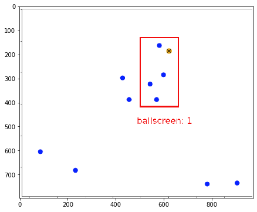

```python
plt.figure(figsize = (10,6));plt.imshow(ballscreen); plt.show()
```

**There is also one stagger screen:**

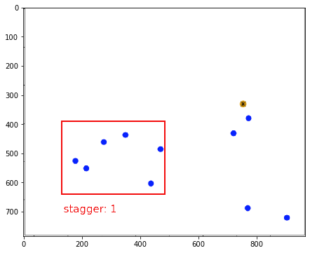

```python
plt.figure(figsize = (10,6));plt.imshow(stagger); plt.show()
```

The goal of the classifier is to learn the relationship between the xy-datapoints and these actions.

Currently, the following are used for classification:

- ANN
- SVM
- RNN with LSTM layers

Based on the lit review, CNNs might be a good idea to try

## Helper functions:

```python
import requests
import json
import numpy as np
import datetime
import pandas as pd
import matplotlib.pyplot as plt
# %matplotlib inline
from shottrackerAPI import shottracker_request, get_possession_ids
from matplotlib.animation import ArtistAnimation
import matplotlib.image as mpimg
ballscreen = mpimg.imread('images/ballscreen.png')
stagger = mpimg.imread('images/stagger.png')
```